# Part I - (Prosper Loan Data Exploration)

## Introduction

> The Prosper loan dataset, provided by Udacity, contains loan information froom different borrowers in United States of America. These data contains about a hundred thousand rows and 81 columns. With how much the columns are, we need a specific area of interest hence, we will need to specify the columns to investigate these area of interests

## Preliminary Wrangling

```python
# import all packages and set plots to be embedded inline
import numpy as np
import pandas as pd
import matplotlib.pyplot as plt
import seaborn as sb
import datetime as datetime

%matplotlib inline
```

```python
#read the dataset and specify the columns of interest
loan_data = pd.read_csv("prosperLoanData.csv", usecols = ['ListingCreationDate', 'CreditGrade', 'Term', 'LoanStatus', 'BorrowerAPR', 'BorrowerRate','ProsperRating (Alpha)', 'ProsperScore', 'ListingCategory (numeric)', 'BorrowerState', 'Occupation', 'EmploymentStatus', 'IsBorrowerHomeowner', 'AvailableBankcardCredit', 'StatedMonthlyIncome',  'LoanOriginalAmount', 'LoanOriginationQuarter', 'Investors', 'MemberKey'])

#displays the dataframe
loan_data.head()
```

|  | ListingCreationDate | CreditGrade | Term | LoanStatus | BorrowerAPR | BorrowerRate | ProsperRating (Alpha) | ProsperScore | ListingCategory (numeric) | BorrowerState | Occupation | EmploymentStatus | IsBorrowerHomeowner | AvailableBankcardCredit | StatedMonthlyIncome | LoanOriginalAmount | LoanOriginationQuarter | MemberKey | Investors |
| --- | --- | --- | --- | --- | --- | --- | --- | --- | --- | --- | --- | --- | --- | --- | --- | --- | --- | --- | --- |
| 0 | 2007-08-26 19:09:29.263000000 | C | 36 | Completed | 0.16516 | 0.1580 | NaN | NaN | 0 | CO | Other | Self-employed | True | 1500.0 | 3083.333333 | 9425 | Q3 2007 | 1F3E3376408759268057EDA | 258 |
| 1 | 2014-02-27 08:28:07.900000000 | NaN | 36 | Current | 0.12016 | 0.0920 | A | 7.0 | 2 | CO | Professional | Employed | False | 10266.0 | 6125.000000 | 10000 | Q1 2014 | 1D13370546739025387B2F4 | 1 |
| 2 | 2007-01-05 15:00:47.090000000 | HR | 36 | Completed | 0.28269 | 0.2750 | NaN | NaN | 0 | GA | Other | Not available | False | NaN | 2083.333333 | 3001 | Q1 2007 | 5F7033715035555618FA612 | 41 |
| 3 | 2012-10-22 11:02:35.010000000 | NaN | 36 | Current | 0.12528 | 0.0974 | A | 9.0 | 16 | GA | Skilled Labor | Employed | True | 30754.0 | 2875.000000 | 10000 | Q4 2012 | 9ADE356069835475068C6D2 | 158 |
| 4 | 2013-09-14 18:38:39.097000000 | NaN | 36 | Current | 0.24614 | 0.2085 | D | 4.0 | 2 | MN | Executive | Employed | True | 695.0 | 9583.333333 | 15000 | Q3 2013 | 36CE356043264555721F06C | 20 |

> Upon creating our preffered dataframe, I can now focus on the variables of interest for investigation, cleaning and analysis of the data

```python
#this lines of code aims to find the structure of the dataset and its properties
print("Dataset Dimension")
print(loan_data.shape)
print('')
print("Data Types")
print(loan_data.dtypes)
print('')
print("Dataset info")
print(loan_data.info())
```

```
Dataset Dimension
(113937, 19)

Data Types
ListingCreationDate           object
CreditGrade                   object
Term                           int64
LoanStatus                    object
BorrowerAPR                  float64
BorrowerRate                 float64
ProsperRating (Alpha)         object
ProsperScore                 float64
ListingCategory (numeric)      int64
BorrowerState                 object
Occupation                    object
EmploymentStatus              object
IsBorrowerHomeowner             bool
AvailableBankcardCredit      float64
StatedMonthlyIncome          float64
LoanOriginalAmount             int64
LoanOriginationQuarter        object
MemberKey                     object
Investors                      int64
dtype: object

Dataset info
<class 'pandas.core.frame.DataFrame'>
RangeIndex: 113937 entries, 0 to 113936
Data columns (total 19 columns):
 #   Column                     Non-Null Count   Dtype
---  ------                     --------------   -----
 0   ListingCreationDate        113937 non-null  object
 1   CreditGrade                28953 non-null   object
 2   Term                       113937 non-null  int64
 3   LoanStatus                 113937 non-null  object
 4   BorrowerAPR                113912 non-null  float64
 5   BorrowerRate               113937 non-null  float64
 6   ProsperRating (Alpha)      84853 non-null   object
 7   ProsperScore               84853 non-null   float64
 8   ListingCategory (numeric)  113937 non-null  int64
 9   BorrowerState              108422 non-null  object
 10  Occupation                 110349 non-null  object
 11  EmploymentStatus           111682 non-null  object
 12  IsBorrowerHomeowner        113937 non-null  bool
 13  AvailableBankcardCredit    106393 non-null  float64
 14  StatedMonthlyIncome        113937 non-null  float64
 15  LoanOriginalAmount         113937 non-null  int64
 16  LoanOriginationQuarter     113937 non-null  object
 17  MemberKey                  113937 non-null  object
 18  Investors                  113937 non-null  int64
dtypes: bool(1), float64(5), int64(4), object(9)
memory usage: 15.8+ MB
None
```

*From the above information about the data, I set out to perform some data assessing and cleaning*

*In the operations to follow i aim to bring the best out of my data*

### Data Assessing and Cleaning

```python
#check for duplicatees
loan_data.duplicated().any()
```

```
False
```

*There are no duplicates in our data hence, i check for null values in the data*

```python
#check for null values
loan_data.isna().any()
```

```
ListingCreationDate          False
CreditGrade                   True
Term                         False
LoanStatus                   False
BorrowerAPR                   True
BorrowerRate                 False
ProsperRating (Alpha)         True
ProsperScore                  True
ListingCategory (numeric)    False
BorrowerState                 True
Occupation                    True
EmploymentStatus              True
IsBorrowerHomeowner          False
AvailableBankcardCredit       True
StatedMonthlyIncome          False
LoanOriginalAmount           False
LoanOriginationQuarter       False
MemberKey                    False
Investors                    False
dtype: bool
```

*i have noted some issues in my dataset and they are liste below*

### Data Cleaning

*Upon Visual assessment of my dataset in Microsoft Excel, I realised that my dataset variables has two categories which are records for data recorded after august 2009 and data recorded before 2009. ProsperScore and ProsperRating (Alpha) contain records applicable for data recorded after august 2009.*

*Firstly, let me convert the ListCreationDate to a datetime data type*

```python
#copy original dataset to a new variable for cleaning
loan_clean = loan_data.copy()

#convert the `ListCreationDate` column to a date time datatype
loan_clean['ListingCreationDate']=pd.to_datetime(loan_clean['ListingCreationDate'])
#show the first five date data
loan_clean['ListingCreationDate'].head()
```

```
0   2007-08-26 19:09:29.263
1   2014-02-27 08:28:07.900
2   2007-01-05 15:00:47.090
3   2012-10-22 11:02:35.010
4   2013-09-14 18:38:39.097
Name: ListingCreationDate, dtype: datetime64[ns]
```

*Given that the CreditGrade and ProsperRating and Score represents different timeframes of the data, analysis requiring these variables would be done for the different timeframes*

*Also, the null values in the BorrowerState, Occupation and EmploymentStatus might not pose a threat to our data analysis as they will be replace with `Not available` for the different variables*

*Next, i want to define a function to replace null values in the categorical variables with Not available*

```python
#this function replaces null values with not available
def rep_null(column):
    loan_clean[column].fillna("Not available",inplace=True)
```

```python
#Applying the function to the desired columns on the data frame
rep_null('BorrowerState')
rep_null('Occupation')
```

*For the EmploymentStatus, replacing the null values with not available will bump up the value of that category already noted in the data set. Since null and not available serves the same meaning, i will do the replacement and proceed with my analysis*

```python
#applying the replace function to my dataset
rep_null('EmploymentStatus')
```

```python
#cehcking the results of my defined operations above
loan_clean.info()
```

```
<class 'pandas.core.frame.DataFrame'>
RangeIndex: 113937 entries, 0 to 113936
Data columns (total 19 columns):
 #   Column                     Non-Null Count   Dtype
---  ------                     --------------   -----
 0   ListingCreationDate        113937 non-null  datetime64[ns]
 1   CreditGrade                28953 non-null   object
 2   Term                       113937 non-null  int64
 3   LoanStatus                 113937 non-null  object
 4   BorrowerAPR                113912 non-null  float64
 5   BorrowerRate               113937 non-null  float64
 6   ProsperRating (Alpha)      84853 non-null   object
 7   ProsperScore               84853 non-null   float64
 8   ListingCategory (numeric)  113937 non-null  int64
 9   BorrowerState              113937 non-null  object
 10  Occupation                 113937 non-null  object
 11  EmploymentStatus           113937 non-null  object
 12  IsBorrowerHomeowner        113937 non-null  bool
 13  AvailableBankcardCredit    106393 non-null  float64
 14  StatedMonthlyIncome        113937 non-null  float64
 15  LoanOriginalAmount         113937 non-null  int64
 16  LoanOriginationQuarter     113937 non-null  object
 17  MemberKey                  113937 non-null  object
 18  Investors                  113937 non-null  int64
dtypes: bool(1), datetime64[ns](1), float64(5), int64(4), object(8)
memory usage: 15.8+ MB
```

*Now, the columns where null values are present can be worked with*

*Next, i want to represent the values of the `ListingCategory(Numeric)` column with proper and understable description*

```python
listing_Cat = {0:"Not Available",
               1:"Debt Consolidation",
               2:"Home Improvement",
               3:"Business",
               4:"Personal Loan",
               5:"Student Use",
               6:"Auto",
               7:"Other",
               8:"Baby&Adoption",
               9:"Boat",
               10:"Cosmetic Procedure",
               11:"Engagement Ring",
               12:"Green Loans",
               13:"Household Expenses",
               14:"Large Purchases",
               15:"Medical/Dental",
               16:"Motorcycle",
               17:"RV",
               18:"Taxes",
               19:"Vacation",
               20:"Wedding Loans",}
def norm_list(x,y=listing_Cat):
    return y[x]
#renames the column
loan_clean.rename(columns={'ListingCategory (numeric)': 'ListingCategory'},inplace=True)

#applies the user defined function above
loan_clean['ListingCategory'] = loan_clean['ListingCategory'].apply(norm_list)
```

```python
#checks the result of the above  operation
loan_clean.head()
```

|  | ListingCreationDate | CreditGrade | Term | LoanStatus | BorrowerAPR | BorrowerRate | ProsperRating (Alpha) | ProsperScore | ListingCategory | BorrowerState | Occupation | EmploymentStatus | IsBorrowerHomeowner | AvailableBankcardCredit | StatedMonthlyIncome | LoanOriginalAmount | LoanOriginationQuarter | MemberKey | Investors |
| --- | --- | --- | --- | --- | --- | --- | --- | --- | --- | --- | --- | --- | --- | --- | --- | --- | --- | --- | --- |
| 0 | 2007-08-26 19:09:29.263 | C | 36 | Completed | 0.16516 | 0.1580 | NaN | NaN | Not Available | CO | Other | Self-employed | True | 1500.0 | 3083.333333 | 9425 | Q3 2007 | 1F3E3376408759268057EDA | 258 |
| 1 | 2014-02-27 08:28:07.900 | NaN | 36 | Current | 0.12016 | 0.0920 | A | 7.0 | Home Improvement | CO | Professional | Employed | False | 10266.0 | 6125.000000 | 10000 | Q1 2014 | 1D13370546739025387B2F4 | 1 |
| 2 | 2007-01-05 15:00:47.090 | HR | 36 | Completed | 0.28269 | 0.2750 | NaN | NaN | Not Available | GA | Other | Not available | False | NaN | 2083.333333 | 3001 | Q1 2007 | 5F7033715035555618FA612 | 41 |
| 3 | 2012-10-22 11:02:35.010 | NaN | 36 | Current | 0.12528 | 0.0974 | A | 9.0 | Motorcycle | GA | Skilled Labor | Employed | True | 30754.0 | 2875.000000 | 10000 | Q4 2012 | 9ADE356069835475068C6D2 | 158 |
| 4 | 2013-09-14 18:38:39.097 | NaN | 36 | Current | 0.24614 | 0.2085 | D | 4.0 | Home Improvement | MN | Executive | Employed | True | 695.0 | 9583.333333 | 15000 | Q3 2013 | 36CE356043264555721F06C | 20 |

*Lets convert some columns to categorical data types to aid grouping*

```python
#code for converting to categorical data types
loan_clean['Occupation'] = loan_clean['Occupation'].astype('category')
loan_clean['BorrowerState'] = loan_clean['BorrowerState'].astype('category')
loan_clean['ListingCategory'] = loan_clean['ListingCategory'].astype('category')
loan_clean['EmploymentStatus'] = loan_clean['EmploymentStatus'].astype('category')
```

```python
#checks results of code above
loan_clean.info()
```

```
<class 'pandas.core.frame.DataFrame'>
RangeIndex: 113937 entries, 0 to 113936
Data columns (total 19 columns):
 #   Column                   Non-Null Count   Dtype
---  ------                   --------------   -----
 0   ListingCreationDate      113937 non-null  datetime64[ns]
 1   CreditGrade              28953 non-null   object
 2   Term                     113937 non-null  int64
 3   LoanStatus               113937 non-null  object
 4   BorrowerAPR              113912 non-null  float64
 5   BorrowerRate             113937 non-null  float64
 6   ProsperRating (Alpha)    84853 non-null   object
 7   ProsperScore             84853 non-null   float64
 8   ListingCategory          113937 non-null  category
 9   BorrowerState            113937 non-null  category
 10  Occupation               113937 non-null  category
 11  EmploymentStatus         113937 non-null  category
 12  IsBorrowerHomeowner      113937 non-null  bool
 13  AvailableBankcardCredit  106393 non-null  float64
 14  StatedMonthlyIncome      113937 non-null  float64
 15  LoanOriginalAmount       113937 non-null  int64
 16  LoanOriginationQuarter   113937 non-null  object
 17  MemberKey                113937 non-null  object
 18  Investors                113937 non-null  int64
dtypes: bool(1), category(4), datetime64[ns](1), float64(5), int64(3), object(5)
memory usage: 12.7+ MB
```

```python
#saves the clean data to a csv file
loan_clean.to_csv("loan_clean.csv", index = False)
```

### What is/are the main feature(s) of interest in your dataset?

> *Here, i am most eager to find out factors that affect the loan status. also, i am interested in the characteristics of borrowers with high loan amount and how the loan amount is related with its interest rate, that is, does a higher loan amount translate to a better loan in terms of interest rate? Hence, the main features of interest in my dataset are those features that will help to effectively find out the answer to the questions listed above*

### What features in the dataset do you think will help support your investigation into your feature(s) of interest?

> *The Loan status, BorrowerRate, ProsperScore, Loan Original amount are some of the features that will aid my investigation into the dataset*

## Univariate Exploration

*In this section, i aim to explore the various columns in my dataset and investigate its distributions and properties*

```python
#show my dataframe
loan_clean.head()
```

|  | ListingCreationDate | CreditGrade | Term | LoanStatus | BorrowerAPR | BorrowerRate | ProsperRating (Alpha) | ProsperScore | ListingCategory | BorrowerState | Occupation | EmploymentStatus | IsBorrowerHomeowner | AvailableBankcardCredit | StatedMonthlyIncome | LoanOriginalAmount | LoanOriginationQuarter | MemberKey | Investors |
| --- | --- | --- | --- | --- | --- | --- | --- | --- | --- | --- | --- | --- | --- | --- | --- | --- | --- | --- | --- |
| 0 | 2007-08-26 19:09:29.263 | C | 36 | Completed | 0.16516 | 0.1580 | NaN | NaN | Not Available | CO | Other | Self-employed | True | 1500.0 | 3083.333333 | 9425 | Q3 2007 | 1F3E3376408759268057EDA | 258 |
| 1 | 2014-02-27 08:28:07.900 | NaN | 36 | Current | 0.12016 | 0.0920 | A | 7.0 | Home Improvement | CO | Professional | Employed | False | 10266.0 | 6125.000000 | 10000 | Q1 2014 | 1D13370546739025387B2F4 | 1 |
| 2 | 2007-01-05 15:00:47.090 | HR | 36 | Completed | 0.28269 | 0.2750 | NaN | NaN | Not Available | GA | Other | Not available | False | NaN | 2083.333333 | 3001 | Q1 2007 | 5F7033715035555618FA612 | 41 |
| 3 | 2012-10-22 11:02:35.010 | NaN | 36 | Current | 0.12528 | 0.0974 | A | 9.0 | Motorcycle | GA | Skilled Labor | Employed | True | 30754.0 | 2875.000000 | 10000 | Q4 2012 | 9ADE356069835475068C6D2 | 158 |
| 4 | 2013-09-14 18:38:39.097 | NaN | 36 | Current | 0.24614 | 0.2085 | D | 4.0 | Home Improvement | MN | Executive | Employed | True | 695.0 | 9583.333333 | 15000 | Q3 2013 | 36CE356043264555721F06C | 20 |

```python
#check the info of the data
loan_clean.info()
```

```
<class 'pandas.core.frame.DataFrame'>
RangeIndex: 113937 entries, 0 to 113936
Data columns (total 19 columns):
 #   Column                   Non-Null Count   Dtype
---  ------                   --------------   -----
 0   ListingCreationDate      113937 non-null  datetime64[ns]
 1   CreditGrade              28953 non-null   object
 2   Term                     113937 non-null  int64
 3   LoanStatus               113937 non-null  object
 4   BorrowerAPR              113912 non-null  float64
 5   BorrowerRate             113937 non-null  float64
 6   ProsperRating (Alpha)    84853 non-null   object
 7   ProsperScore             84853 non-null   float64
 8   ListingCategory          113937 non-null  category
 9   BorrowerState            113937 non-null  category
 10  Occupation               113937 non-null  category
 11  EmploymentStatus         113937 non-null  category
 12  IsBorrowerHomeowner      113937 non-null  bool
 13  AvailableBankcardCredit  106393 non-null  float64
 14  StatedMonthlyIncome      113937 non-null  float64
 15  LoanOriginalAmount       113937 non-null  int64
 16  LoanOriginationQuarter   113937 non-null  object
 17  MemberKey                113937 non-null  object
 18  Investors                113937 non-null  int64
dtypes: bool(1), category(4), datetime64[ns](1), float64(5), int64(3), object(5)
memory usage: 12.7+ MB
```

```python
#checks the statistical figures for each column
loan_clean.describe()
```

|  | Term | BorrowerAPR | BorrowerRate | ProsperScore | AvailableBankcardCredit | StatedMonthlyIncome | LoanOriginalAmount | Investors |
| --- | --- | --- | --- | --- | --- | --- | --- | --- |
| count | 113937.000000 | 113912.000000 | 113937.000000 | 84853.000000 | 106393.000000 | 1.139370e+05 | 113937.00000 | 113937.000000 |
| mean | 40.830248 | 0.218828 | 0.192764 | 5.950067 | 11210.225447 | 5.608026e+03 | 8337.01385 | 80.475228 |
| std | 10.436212 | 0.080364 | 0.074818 | 2.376501 | 19818.361309 | 7.478497e+03 | 6245.80058 | 103.239020 |
| min | 12.000000 | 0.006530 | 0.000000 | 1.000000 | 0.000000 | 0.000000e+00 | 1000.00000 | 1.000000 |
| 25% | 36.000000 | 0.156290 | 0.134000 | 4.000000 | 880.000000 | 3.200333e+03 | 4000.00000 | 2.000000 |
| 50% | 36.000000 | 0.209760 | 0.184000 | 6.000000 | 4100.000000 | 4.666667e+03 | 6500.00000 | 44.000000 |
| 75% | 36.000000 | 0.283810 | 0.250000 | 8.000000 | 13180.000000 | 6.825000e+03 | 12000.00000 | 115.000000 |
| max | 60.000000 | 0.512290 | 0.497500 | 11.000000 | 646285.000000 | 1.750003e+06 | 35000.00000 | 1189.000000 |

*Now, using visualizations, i want to investigate my data distribution*

```python
#Setting the plot style
plt.style.use('ggplot')
```

```python
#define the function that plots an histogram showing the data distribution
def plot_func(column, title, binsize):#title is the proposed
                                    #title of the chart and binsize specifies the size of the bins in the column
    bins = np.arange(loan_clean[column].min(), loan_clean[column].max()+binsize, binsize)

    loan_clean[column].plot(kind = 'hist', figsize = (7,5), color = "#C13016", bins = bins);#plots a bar chart

    plt.title(label = title, fontsize = 16);#prints the title
```

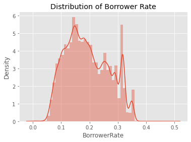

```python
#this plots a density curve distribution of the interest rate for borrowers
sb.distplot(loan_clean['BorrowerRate'])
plt.title('Distribution of Borrower Rate');
```

*From the above density plot,one can notice the curve peaked at the 0.1 - 0.2 value with a spike also at interest values greater than 0.3*

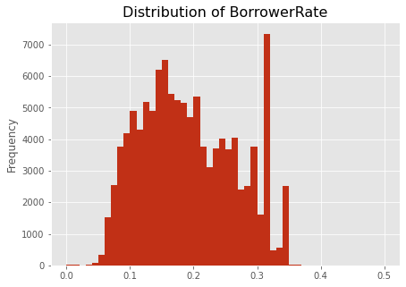

```python
#applying the function to the BorrowerRate Column
plot_func('BorrowerRate', 'Distribution of BorrowerRate',0.01)
```

*The histogram above shows the distribution of borrowerRate with binsize = 0.01. Where most of the borrowers have a rate between the range of 0.1 to 0.2. Also there seem to be an increased number of borrowers with the interest rate greater than 0.3*

**Distribution of the BorrowerAPR**

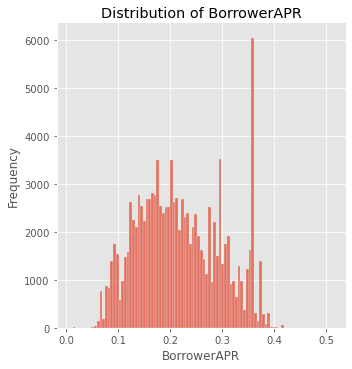

```python
#this code plots an histogram showing the distribution of the borrower annual percentage Rate
sb.displot(loan_clean['BorrowerAPR'], kde = False)

plt.title('Distribution of BorrowerAPR');
plt.ylabel('Frequency');
```

*The plot above displays the distribution of the BorrowerAPR for borrowers. It shows a normal distribution and also a spike in BorrowerAPR between the 0.3-0.4 value.*

*Now, given that the prosperScore is applicable for records taken after July 2009, to properly check its distribution ,i will create a dataframe that captures the required range*

```python
#creates the needed dataframe containing the needed range
loan_upper = loan_clean[loan_clean['ListingCreationDate'].dt.date> datetime.date(2009,8,1)]
```

```python
#saves the new dataframe to a csv file
loan_upper.to_csv("loan_upper.csv", index = False)
```

```python
#shows the info of the required range
loan_upper.info()
```

```
<class 'pandas.core.frame.DataFrame'>
Int64Index: 84669 entries, 1 to 113936
Data columns (total 19 columns):
 #   Column                   Non-Null Count  Dtype
---  ------                   --------------  -----
 0   ListingCreationDate      84669 non-null  datetime64[ns]
 1   CreditGrade              0 non-null      object
 2   Term                     84669 non-null  int64
 3   LoanStatus               84669 non-null  object
 4   BorrowerAPR              84669 non-null  float64
 5   BorrowerRate             84669 non-null  float64
 6   ProsperRating (Alpha)    84669 non-null  object
 7   ProsperScore             84669 non-null  float64
 8   ListingCategory          84669 non-null  category
 9   BorrowerState            84669 non-null  category
 10  Occupation               84669 non-null  category
 11  EmploymentStatus         84669 non-null  category
 12  IsBorrowerHomeowner      84669 non-null  bool
 13  AvailableBankcardCredit  84669 non-null  float64
 14  StatedMonthlyIncome      84669 non-null  float64
 15  LoanOriginalAmount       84669 non-null  int64
 16  LoanOriginationQuarter   84669 non-null  object
 17  MemberKey                84669 non-null  object
 18  Investors                84669 non-null  int64
dtypes: bool(1), category(4), datetime64[ns](1), float64(5), int64(3), object(5)
memory usage: 10.1+ MB
```

*The creditGrade records all values as null given that its values are that of a different range which is before July 2009. ProsperRating and ProsperScore contains values with records specified for the date range of the dataframe*

*Next, i will investigate these variables*

```python
#shows the properties of the required range
loan_upper.describe()
```

|  | Term | BorrowerAPR | BorrowerRate | ProsperScore | AvailableBankcardCredit | StatedMonthlyIncome | LoanOriginalAmount | Investors |
| --- | --- | --- | --- | --- | --- | --- | --- | --- |
| count | 84669.000000 | 84669.000000 | 84669.000000 | 84669.000000 | 84669.000000 | 8.466900e+04 | 84669.000000 | 84669.000000 |
| mean | 42.500230 | 0.226737 | 0.196087 | 5.945104 | 11390.845811 | 5.933578e+03 | 9094.257981 | 68.102033 |
| std | 11.649055 | 0.079887 | 0.074603 | 2.375364 | 18599.152482 | 8.247842e+03 | 6288.595873 | 95.056838 |
| min | 12.000000 | 0.049350 | 0.040000 | 1.000000 | 0.000000 | 0.000000e+00 | 1000.000000 | 1.000000 |
| 25% | 36.000000 | 0.163610 | 0.135900 | 4.000000 | 1146.000000 | 3.441667e+03 | 4000.000000 | 1.000000 |
| 50% | 36.000000 | 0.219450 | 0.187500 | 6.000000 | 4567.000000 | 5.000000e+03 | 7500.000000 | 31.000000 |
| 75% | 60.000000 | 0.292540 | 0.257400 | 8.000000 | 13900.000000 | 7.083333e+03 | 13750.000000 | 97.000000 |
| max | 60.000000 | 0.423950 | 0.360000 | 11.000000 | 498374.000000 | 1.750003e+06 | 35000.000000 | 1189.000000 |

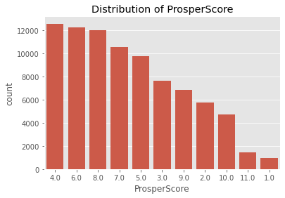

```python
#creates a bar chart reping the different scores
order = loan_clean['ProsperScore'].value_counts().index

base_color = sb.color_palette()[0]#set color to uniform
sb.countplot(data = loan_upper, x = 'ProsperScore', color = base_color, order = order)
plt.title('Distribution of ProsperScore');
```

*Interestingly, the worst risk score has the lowest distribution in our data where risk scores 4, 6 and 8 have the higher distribution in our data. Simply put, most of the loans taken by borrowers are low risk loans with only a small percentage being high risk loans*

*Next up, what is the distribution of the ProsperRating for the loans? given that AA is the best rating a loan can get, how many of the loans were rated AA and also the rating distribution over the entire dataset*

```python
#set the column as ordered category
ordinal_var_dict = ['HR','E','D','C', 'B', 'A', 'AA']
ordered_var = pd.api.types.CategoricalDtype(ordered = True, categories = ordinal_var_dict)
loan_upper['ProsperRating (Alpha)'] = loan_upper['ProsperRating (Alpha)'].astype(ordered_var)
```

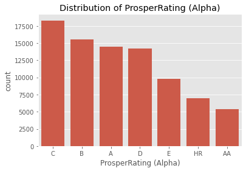

```python
#creates a bar chart reping the different ratings
base_color = sb.color_palette()[0]#set color to uniform

#sets an order for the bar plot
order = loan_clean['ProsperRating (Alpha)'].value_counts().index
sb.countplot(data = loan_upper, x = 'ProsperRating (Alpha)', color = base_color, order = order)
plt.title('Distribution of ProsperRating (Alpha)');
```

*Here, it is shown above that most of the rating can be found under the C rating which is still fair. Also the lowest amount of distributions is the best rating- AA*

*Prosper Rating are assigned a value between AA - HR at the time the listing was created. ProsperRating column is an ordered categorical column. Ratings range from AA, A, B, C, D, E to HR where AA is the lowest risk down to HR which stands for 'high risk'.*

*Still on categorical variables, i will like to inspect how long each loan is expected to last for. From the variable `Term`, which captures the the length of the loan expressed in months. i can use seaborn countplot or matplotlib bar chart to find the distribution of each term for*

### Distribution of Borrowers across the given Length of Loan

```python
#this line of code checks the distribution of the length of the loan
loan_clean['Term'].value_counts()
```

```
36    87778
60    24545
12     1614
Name: Term, dtype: int64
```

*Hence, i will plot the results above as a proportion on a bar chart*

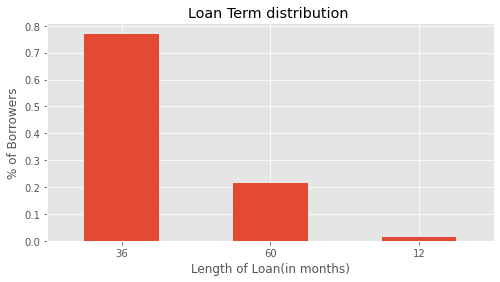

```python
loan_clean['Term'].value_counts(normalize=True).plot(kind='bar', figsize=[8,4], title='Loan Term distribution ')

plt.ylabel('% of Borrowers');
plt.xlabel('Length of Loan(in months)');
plt.xticks(rotation = 360);
```

*From the above plots, it is evident that loans with length of 3 years were most collected by the borrowers with more than 70% followed by 5 years*

```python
#this line of code checks the disttibution of loanStatus
loan_clean['LoanStatus'].value_counts()
```

```
Current                   56576
Completed                 38074
Chargedoff                11992
Defaulted                  5018
Past Due (1-15 days)        806
Past Due (31-60 days)       363
Past Due (61-90 days)       313
Past Due (91-120 days)      304
Past Due (16-30 days)       265
FinalPaymentInProgress      205
Past Due (>120 days)         16
Cancelled                     5
Name: LoanStatus, dtype: int64
```

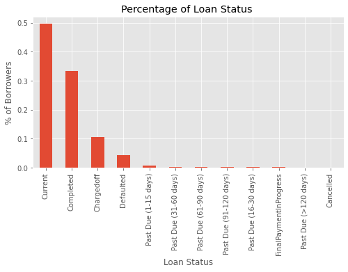

```python
#plots the categorical variable on a bar chart with the height representing the percentage of each variable
(loan_clean['LoanStatus'].value_counts(normalize=True)).plot(kind='bar', figsize=[8,4], title='Percentage of Loan Status ')

plt.ylabel('% of Borrowers');
plt.xlabel('Loan Status');
```

*looking at the above plot i can see that loans that are past their due date have so many categories hence, i will classify all loans past their due date as delinquent. That is i will create a new category `Past Due` which will represent all loans that are past due date and then rerun the above code*

```python
#this line of code replaces the different ranges of the past due date with one generic name for all pat due loans
col = 'LoanStatus'
loan_clean.loc[loan_clean[col].str.startswith("Past Due"), col] = "Past Due"
```

```python
#sets the above columns as a category
loan_clean['LoanStatus'] = loan_clean['LoanStatus'].astype('category')
```

*Now , i attempt to replot the results of the above operation*

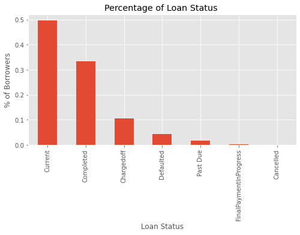

```python
#plots the categorical variable on a bar chart with the height representing the percentage of each variable
(loan_clean['LoanStatus'].value_counts(normalize=True)).plot(kind='bar', figsize=[8,4], title='Percentage of Loan Status ')

plt.ylabel('% of Borrowers');
plt.xlabel('Loan Status');
```

**The Distribution of bank card Credit available for Borrowers**

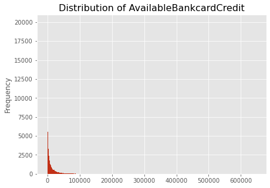

```python
#using the predefined function to check its distribution
plot_func('AvailableBankcardCredit', 'Distribution of AvailableBankcardCredit',500)
```

*Here, i decided to plot my distribution using a log scale and transformation.This was after checking the results obtained plotting on a normal scale*

```python
#find the log scale of the mean, median and mode
np.log10(loan_clean['AvailableBankcardCredit'].describe())
```

```
count    5.026913
mean     4.049614
std      4.297068
min          -inf
25%      2.944483
50%      3.612784
75%      4.119915
max      5.810424
Name: AvailableBankcardCredit, dtype: float64
```

*The `-inf` in the minimum variable is caused by the value being equal to 0. I then set the value to be equal to 0.01 close to 0 in order to be able to properly set my x limit*

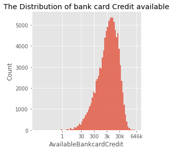

```python
#set the bin sizes
bins = 10 ** np.arange(-2, 5.8+0.1, 0.1)

#creates an histogram using seaborn function
sb.displot(loan_clean['AvailableBankcardCredit'], kde = False, bins = bins ,height = 4)

plt.title('The Distribution of bank card Credit available');

#set xticks and labels
ticks =  [ 1,30,300, 3e3, 30e3, 646e3]
labels = ['1', '30', '300', '3k', '30k', '646k']

plt.xscale('log');

plt.xticks(ticks, labels);
```

*From the above histogram, it can be deduced that most of the borrowers have a available Bank card credit between the 3k and 30k amount*

*This can be seen as the histogram is skewed to the left*

**Distribution of the LoanOriginalAmount**

*In order to answer some of the questions i posed, i will investigate the distribution of loan amount taken by borrowers*

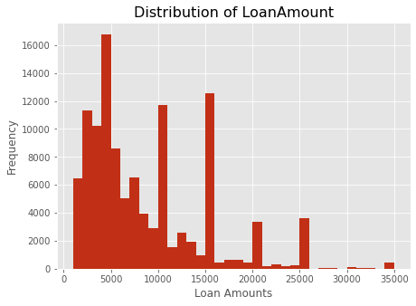

```python
#applying the user defined function to my dataset
plot_func('LoanOriginalAmount', 'Distribution of LoanAmount', 1000)

#set the xlabel
plt.xlabel('Loan Amounts');
```

*Here, the plot shows price points in out dataset where there are increase in the number of borrowers that took that much loan*

### Distribution of Stated Monthly Income

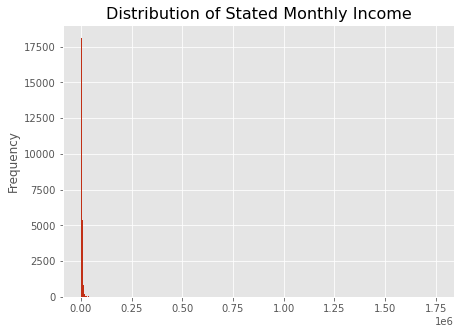

```python
#using the defined function to plot the distribution
plot_func('StatedMonthlyIncome', 'Distribution of Stated Monthly Income', 1000)
```

*Its is obvious that the plot above will need some transformation and scaling to be able to properly plot the required data on the histogram. Hence, the plot will be more readable by the consumer of the visualization*

```python
loan_clean['StatedMonthlyIncome'].describe()
```

```
count    1.139370e+05
mean     5.608026e+03
std      7.478497e+03
min      0.000000e+00
25%      3.200333e+03
50%      4.666667e+03
75%      6.825000e+03
max      1.750003e+06
Name: StatedMonthlyIncome, dtype: float64
```

```python
#the statistical characteristics of my dataset
np.log10(loan_clean['StatedMonthlyIncome'].describe())
```

```
count    5.056665
mean     3.748810
std      3.873814
min          -inf
25%      3.505195
50%      3.669007
75%      3.834103
max      6.243039
Name: StatedMonthlyIncome, dtype: float64
```

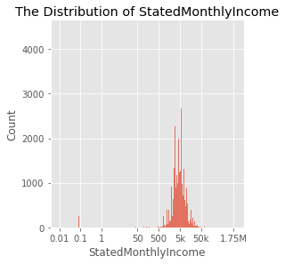

```python
plt.figure(figsize = [10,6]);
#set the bin sizes
bins = 10 ** np.arange(-2, 6.3+0.01, 0.01)

#creates an histogram using seaborn function
sb.displot(loan_clean['StatedMonthlyIncome'], kde = False, bins = bins ,height = 4)

plt.title('The Distribution of StatedMonthlyIncome');

#set xticks and labels
ticks =  [0.01, 0.1, 1,50,500, 5e3, 50e3, 1.75e6]
labels = ['0.01', '0.1', '1', '50', '500', '5k', '50k', '1.75M']

plt.xscale('log');

plt.xticks(ticks, labels);
```

*The histogram above shows that most of the borrower'stated monthly income is between 4000 - 6000 USD as the histogram reaches it peak value at those points. It also confirms that the maximum value of the stated monthly income is an outlier*

### Discuss the distribution(s) of your variable(s) of interest. Were there any unusual points? Did you need to perform any transformations?

> Using seaborn displot and matplotlib's `plt.hist()` for non-categorical variables and using seaborn countplot for categorical variables, i have being able to investigate the distribution of the data set. Interestingly, about 50% of the loans are currently on with 30% completed. I have also noticed that most of the loans do not have the best risk score and rating by Prosper but an higher percentage of the loans were considered low risk loans given by their ProsperScore. About 80% of the loans have a loan term of 3 years with the remaining percent shared between the 5-Year and 1-year term. There was a need to perform log transformations on the `StatedMonthlyIncome` and `AvailableBankCardCredit` column in order to properly and effectively show the distributions of the values across the borrowers.

### Of the features you investigated, were there any unusual distributions? Did you perform any operations on the data to tidy, adjust, or change the form of the data? If so, why did you do this?

> Yes, with regards to the `statedMonthlyIncome` and `Available Bank Card credit`, i notice outliers in the values which affected distribution shown in the histogrm. I had to perform a log transformation to the data in order to be able to properly plot the data on a histogram. I also had to reorganize the `LoanStaus` categorical variables. The past due loans were summed up into one category to reduce redundancy.

## Bivariate Exploration

> *In this section, i will investigate relationships between pairs of variables in the* *data. i also made sure the variables that i covered here have been introduced in some* *fashion in the previous section (univariate exploration).*

> *Firstly, i want to investigate the relationship between the `BorroewerAPR` and `BorrowerRate` column. From my research, i discovered that the borrowerAPR is higher than the borrower rate. The APR figures in not just your interest rate, but also some fees associated with your loan over its lifetime. At Prosper, this means the closing fee charged when you first borrow the money. This closing fee is paid out of the loan proceeds when the loan originates.*

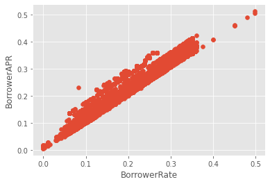

```python
#using a scatter plot to investigate the relationship between the to variables
plt.scatter(data = loan_clean, x = "BorrowerRate", y = "BorrowerAPR");
plt.xlabel("BorrowerRate");
plt.ylabel("BorrowerAPR");
```

*As expected, due to their very close definitions they happen to have a linear relationship. that is as the borrower rate incresases, so is the borrower APR.*

> Next up, i will like to investigate the how the interest rate which is also the borrower rate relates original loan amoutn given to the borrower for each loan

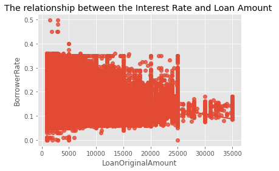

```python
#using seaborn regplot, i want to find the relationship btw the two variables
sb.regplot(data = loan_clean, y = 'BorrowerRate', x = 'LoanOriginalAmount', x_jitter = 0.2);

#set the title
plt.title("The relationship between the Interest Rate and Loan Amount ");
```

*From the above, the need to use a smaller portion of the data arises. Next, i will select randomly a subset of the data to work on*

```python
#setup a random sample from the original dataset
np.random.seed(2018)
sample = np.random.choice(loan_clean.shape[0], 500, replace = False)
loan_clean_subset = loan_clean.loc[sample]
```

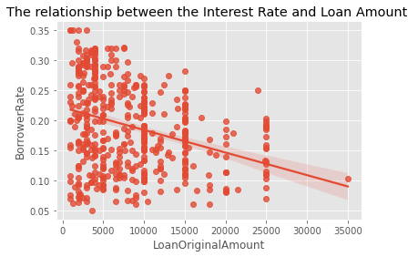

```python
#using seaborn regplot, i want to find the relationship btw the two variables
sb.regplot(data = loan_clean_subset, y = 'BorrowerRate', x = 'LoanOriginalAmount', x_jitter = 0.2);

#set the title
plt.title("The relationship between the Interest Rate and Loan Amount ");
```

*Well, it happens that i can not find anything interesting here. Hence, i will proceed with my analysis and look to investigate their relationship more in the multivariate exploration section. However, i notice that the points are less packed at loan amounts higher than 5000 USD.So its safe to assume that the lesser the loan amount, the higher the interest rate.*

> Next, looking at the loan status column, i wil like to investigate how each category of the column relates with the loan amount taken by the borrowers.

```python
# the different categories of loan status available
statuses = ['Current', 'Completed', 'Chargedoff', 'Defaulted', 'Past Due', 'FinalPaymentInProgress', 'Cancelled']

# returns the ordered version
statuses = pd.api.types.CategoricalDtype(ordered=True, categories=statuses)

# Use pandas.astype() to convert the "LoanStatus" column from a plain object type into an ordered categorical type
loan_clean['LoanStatus'] = loan_clean['LoanStatus'].astype(statuses);
```

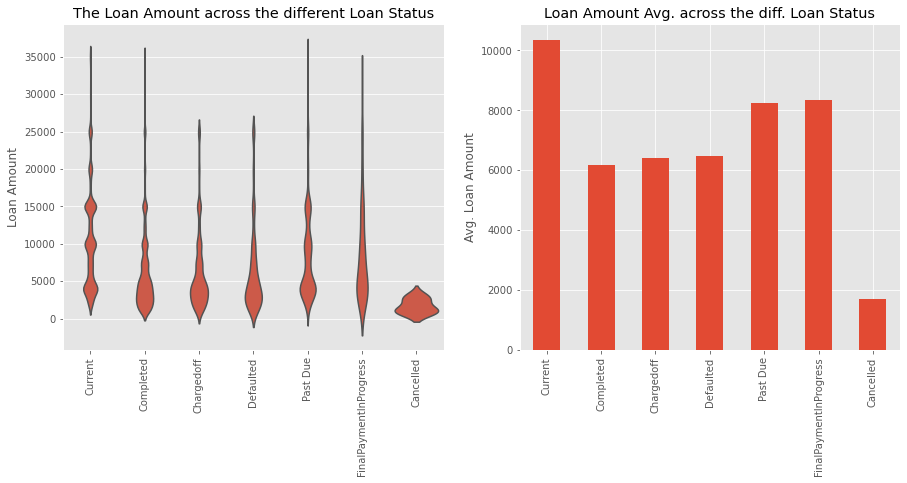

```python
plt.figure(figsize = [15, 6])

# sets the color of the violin plot
base_color = sb.color_palette()[0]

plt.subplot(1,2,1)
sb.violinplot(data = loan_clean, x = "LoanStatus", y = "LoanOriginalAmount", inner = None
             , color = base_color);
# rotates each tick label by 90 degrees
plt.xticks(rotation = 90);
plt.xlabel('');
plt.ylabel('Loan Amount');
plt.title('The Loan Amount across the different Loan Status');

plt.subplot(1,2,2)
#plot the above on a bar chart
loan_clean.groupby(['LoanStatus'])['LoanOriginalAmount'].mean().plot(kind = 'bar');
plt.title('Loan Amount Avg. across the diff. Loan Status');
plt.xlabel('')
plt.ylabel('Avg. Loan Amount');
```

```python
#assign to a variable
loan_clean.groupby(['LoanStatus'])['LoanOriginalAmount'].mean().reset_index().sort_values(by = 'LoanOriginalAmount',ascending=False)
```

|  | LoanStatus | LoanOriginalAmount |
| --- | --- | --- |
| 0 | Current | 10360.835018 |
| 5 | FinalPaymentInProgress | 8346.121951 |
| 4 | Past Due | 8258.437349 |
| 3 | Defaulted | 6486.798525 |
| 2 | Chargedoff | 6398.916694 |
| 1 | Completed | 6189.093239 |
| 6 | Cancelled | 1700.000000 |

*Clearly, from the above plot, for each loan status,loan amounts less than 5000 have the most distribution. This can be attributed to the histogram showin the distribution of the loan amount which shows that most of the borrowers took a loan below 5000 had the highest frequency. Also notice that the loan amount associated with Current, Completed and past due categories happen to be more spread out, having outliers as high as 35000 dollars. All of the cancelled loans have amount not higher than 5000. i am assuming this is in an attempt to reduced bad debt*

*It is also clear here that the loans currently on have the highest loan amount on average, followed by the category whose final payment is in progress. It also looks like for completed loans, not a lot of money have being paid on average. This seems bad for buisness as quite a number of the loans are currently on and not a lot have being paid back*

> *Going forward,how does the prosper score and rating affects the interest rate for the loan taken by the borrowers?*

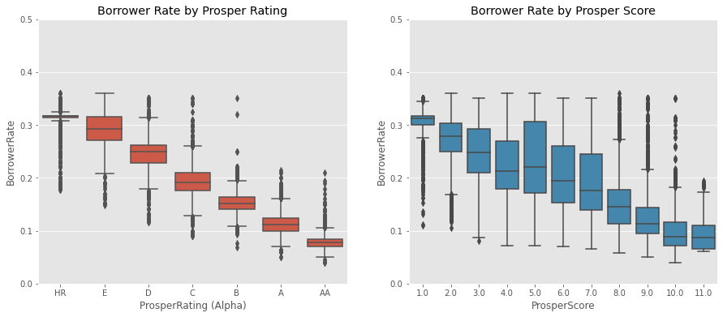

```python
# Plotting a boxplot and using subplots
plt.figure(figsize = [15, 6])
plt.subplot(1, 2, 1)

sb.boxplot(data=loan_upper, x='ProsperRating (Alpha)', y='BorrowerRate', \
              color = sb.color_palette()[0])
plt.ylim(0, 0.5)
plt.title('Borrower Rate by Prosper Rating');

#second subplot
plt.subplot(1, 2, 2)
sb.boxplot(data=loan_upper, x='ProsperScore', y='BorrowerRate', \
              color = sb.color_palette()[1])
plt.ylim(0, 0.5);
plt.title('Borrower Rate by Prosper Score');
```

*Very quickly noticed is the similarities in the trends of the two plots. Where 1.0 indicates a high risk loan, so does 'HR' indicates a high risk loan. Also one will notice that there is a decrease in the median of the interest rate as the risk scores and ratings improve. simply put, there is a strong negative correlation between the variables.*

> *Next, i will like to investigate the loan term associated with each loan status using a clustered bar chart.*

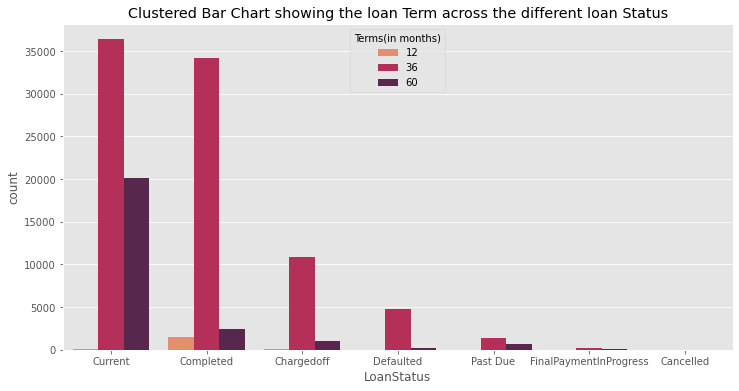

```python
# Bar Chart between two ordered categorical varibles
plt.figure(figsize = [12, 6])
sb.countplot(data = loan_clean, hue = 'Term', x = 'LoanStatus', palette = 'rocket_r')
plt.title('Clustered Bar Chart showing the loan Term across the different loan Status');
plt.legend(title = 'Terms(in months)');
```

*Here, i notice that most of the current loans have their length to be 3 years(36 months). Also, for loan term of one year, most of these loans have been completed already as shown on the clustered bar chart. Below, i attempt to show the counts more clearly after performing some operations and reorganizing my columns*

```python
#regroup the required columns
grouping = loan_clean.groupby(["LoanStatus", "Term"]).size()

# reset the index and rename it
grouping = grouping.reset_index(name = "group")

# organize the results into index and columns
grouping = grouping.pivot(index = "LoanStatus", columns = "Term", values = "group")

#show results
grouping
```

| Term LoanStatus | 12 | 36 | 60 |
| --- | --- | --- | --- |
| Current | 62 | 36387 | 20127 |
| Completed | 1450 | 34200 | 2424 |
| Chargedoff | 72 | 10834 | 1086 |
| Defaulted | 10 | 4822 | 186 |
| Past Due | 10 | 1373 | 684 |
| FinalPaymentInProgress | 10 | 157 | 38 |
| Cancelled | 0 | 5 | 0 |

*Plotting the results above on a heatmap:*

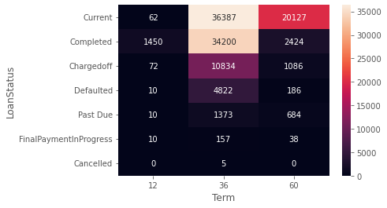

```python
# a heat map using seaborn
sb.heatmap(grouping, fmt = 'd', annot = True);
```

*The heatmap above shows that most of the loans are currently on and they have a loan term of 3 years. It is also safe to say that the shorter the loan term the quicker it is to being completed*

> *Furthermore, investigating the loan amount taken by borrowers, i plot the bar plot for each category of borrower showing their employment status in order to know how the average loan amount varies for their different Employment status. Do self employed borrowers have access to higher loans?*

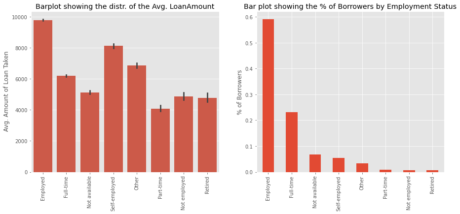

```python
base_color = sb.color_palette()[0]#sets the color to one instead of multiple

plt.figure(figsize = [15, 6])
plt.subplot(1, 2, 1)

#line of code to plot the bar chart
sb.barplot(data = loan_clean, x = 'EmploymentStatus', y = 'LoanOriginalAmount' ,color = base_color,
           order = loan_clean['EmploymentStatus'].value_counts().index)

plt.xticks(rotation = 90);

plt.title('Barplot showing the distr. of the Avg. LoanAmount')
plt.xlabel('');
plt.ylabel(' Avg. Amount of Loan Taken');

plt.subplot(1,2,2)
loan_clean['EmploymentStatus'].value_counts(normalize = True).plot(kind = 'bar', title = 'Bar plot showing the % of Borrowers by Employment Status');
plt.ylabel('% of Borrowers');
```

```python
#using groupby method to properly show the results plotted above
loan_clean.groupby(['EmploymentStatus'])['LoanOriginalAmount'].mean()
```

```
EmploymentStatus
Employed         9794.017988
Full-time        6194.779017
Not available    5132.360431
Not employed     4872.659880
Other            6861.727010
Part-time        4088.772059
Retired          4784.145912
Self-employed    8122.836485
Name: LoanOriginalAmount, dtype: float64
```

> Next up, i will also invesstigate the characteristics of borrowers with high loan amounts. This group will be selected for loan amount greater than the median loan amount.

```python
#using seaborn to display graphs n desired order set by the order variable
g = sb.FacetGrid(data = loan_clean, col = 'LoanStatus', col_wrap = 4)
g.map(plt.bar, 'EmploymentStatus', height = 4);
plt.xticks(rotation = 90);
```

[output not shown]

```python
#creates a dataframe of borrowers with loan amount greater than the median
big_loan_amt = loan_clean[loan_clean['LoanOriginalAmount'] > loan_clean['LoanOriginalAmount'].median()]
```

*here, i will like to investigate the realtionships between the interest rate and the loan amounts*

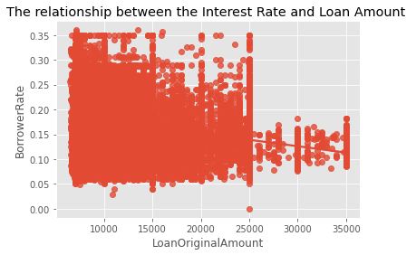

```python
#using seaborn regplot, i want to find the relationship btw the two variables
sb.regplot(data =big_loan_amt, y = 'BorrowerRate', x = 'LoanOriginalAmount', x_jitter = 0.2);

#set the title
plt.title("The relationship between the Interest Rate and Loan Amount ");
```

*Quite suprising that for this group of borrowers too, there happens to a steep decrease in the interest rate for loan amounts greater 25 000 USD as loan amounts after this value simply have their interest rate range between 0.20% and 0.05%. An interesting fact is that the loan amounts does not totaaly determines the interest rate of the loan. Take a look at the maximum loan amount, same amount buh multiple interest rate. In the coming sections, i will like to investigate the cause for the change in interest rates*

```python
loan_clean.columns
```

```
Index(['ListingCreationDate', 'CreditGrade', 'Term', 'LoanStatus',
       'BorrowerAPR', 'BorrowerRate', 'ProsperRating (Alpha)', 'ProsperScore',
       'ListingCategory', 'BorrowerState', 'Occupation', 'EmploymentStatus',
       'IsBorrowerHomeowner', 'AvailableBankcardCredit', 'StatedMonthlyIncome',
       'LoanOriginalAmount', 'LoanOriginationQuarter', 'MemberKey',
       'Investors'],
      dtype='object')
```

### Talk about some of the relationships you observed in this part of the investigation. How did the feature(s) of interest vary with other features in the dataset?

> Amazing section it is. I spotted quite a lot o relationships between my variables of interest and discovered some notes. Firstly, the interest rate is not entierly based on the Amount of the loan. also, It is clear that for each category of `loanStatus`,its frequency among the loans does not determine the average loan amount taken by that category as categories with more loans had even lower average loan amount taken. furthermore,I noticed that there is a decrease in the median of the interest rate as the risk scores and ratings improve. For the Loan term, the loan term of one year have most of their loans have been completed already. for the one year, the completed loans form the highest percentage amongst other loanStatus category at over 90%. It also looks like for completed loans, not a lot of money have being paid on average but loans with their final payment in progress also happens to have a high average Loan amount, second to the average loan amount from loans that are currently on.

### Did you observe any interesting relationships between the other features (not the main feature(s) of interest)?

> The `EmploymentStatus` looks like it might have an effect. Employed borrowers have the highest average of loan amount taken while It is also clear that the frequency of each category among the borrowers does not determine the average loan amount taken.This is clear as the self employed category has a percentage of less than 10% among the borrowers and still has the second highest average loan amount when compared to the employed category accounting for over 50% of the borrowers.

## Multivariate Exploration

> i created plots of three or more variables to investigate my data even further. i made sure that my investigations are justified, and follow from the work in the previous sections.

> Here, i would like to further my investigation into the Relationship between the interest rate and loan amount taken. Using seaborn FacetGrid function, i can understand the relationship between this variables while using another variable as reference. This other variable is the ProsperRating variable.

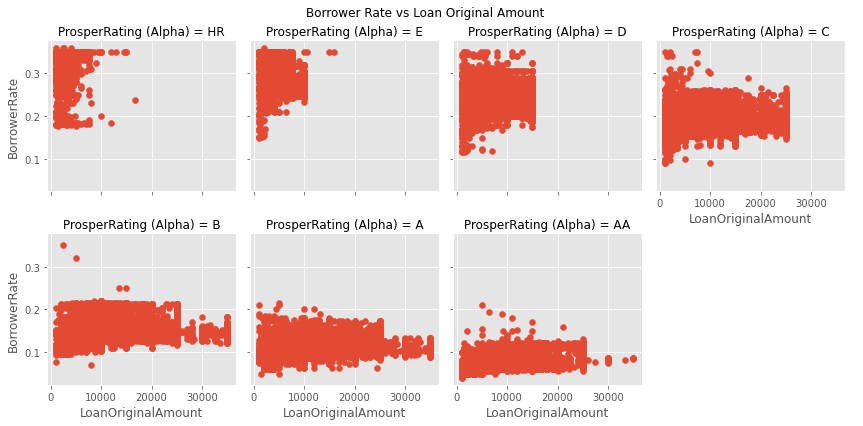

```python
# Create faceted scatter plot on levels of Prosper Rating
g = sb.FacetGrid(data = loan_clean, col = 'ProsperRating (Alpha)', col_wrap=4, col_order = ordinal_var_dict )
g.map(plt.scatter, 'LoanOriginalAmount', 'BorrowerRate')
g.add_legend()
g.fig.subplots_adjust(top=0.9)
g.fig.suptitle('Borrower Rate vs Loan Original Amount');
```

*Notice how for ProsperRating other than AA, A and B, there is a high concentration of loans with interest rate greater than 0.1. This simply confirms the point raised in the Bivariate exploration section that there is more to the interest than just the loan amount taken. This plot shows that the Prosper Rating of the Borrower makes an impact on the trading.*

> Furthermore from the bivariate section, let us look at how the plot above is related to the loan status.

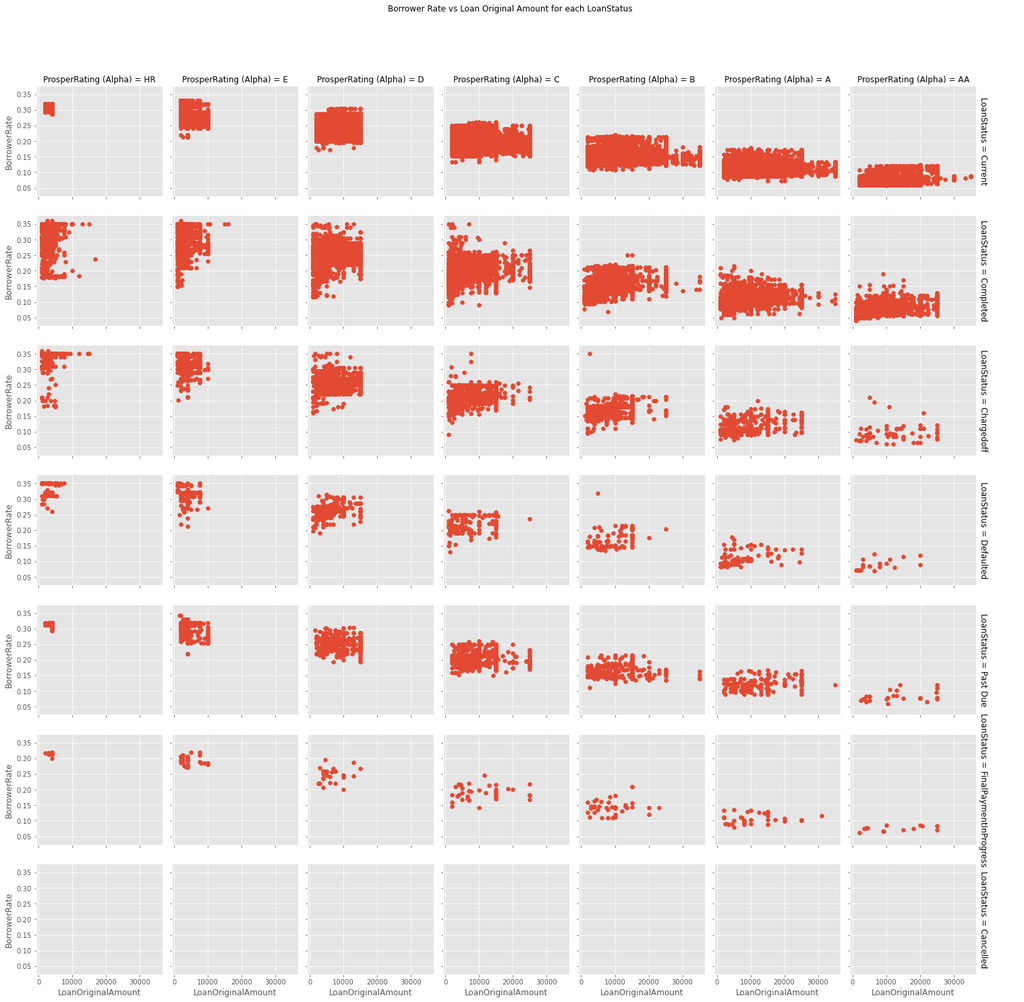

```python
#this line of code uses facetgrid to plot ,ultiple visualizations

v = sb.FacetGrid(data = loan_clean, col = 'ProsperRating (Alpha)', col_order = ordinal_var_dict,
                 row = 'LoanStatus',
                 margin_titles = True,
                 sharey=True)
v.map(plt.scatter,'LoanOriginalAmount', 'BorrowerRate');

v.add_legend()
v.fig.subplots_adjust(top=0.9)
v.fig.suptitle('Borrower Rate vs Loan Original Amount for each LoanStatus');
```

*Though messy but it has a lot of information about the data. Generally, the interest rate increases as the ProsperRating decreases. Also notice that those whose final payment is in progress and have the best prosper rating have very low interest rates and are even fewer. Even the Loans with the best prosper rating were defaulted but this loans had very small interest rates. Only loans with prosper rating A and AA and also completed have the lowest interest rates with some loans having interest rate below 0.05%.*

> Finally, i will use a pointplot to represents an estimate of central tendency for a BorrowerRAte variable by the position of scatter plot points and provides some indication of the uncertainty around that estimate using error bars.

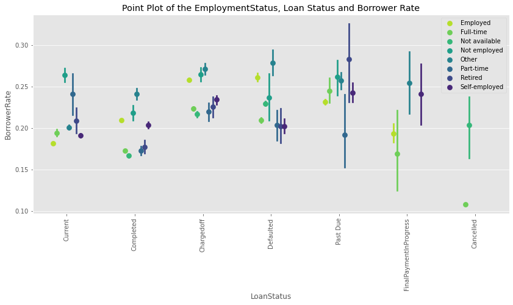

```python
# a point plot
plt.figure(figsize = [14,6])
sb.pointplot(data = loan_clean, hue = 'EmploymentStatus', y = 'BorrowerRate', x='LoanStatus',\
             dodge = 0.4, linestyles = "", palette='viridis_r');
plt.xticks(rotation=90)
plt.legend(loc='upper right')
plt.title('Point Plot of the EmploymentStatus, Loan Status and Borrower Rate');
```

### Talk about some of the relationships you observed in this part of the investigation. Were there features that strengthened each other in terms of looking at your feature(s) of interest?

> For ProsperRating other than AA, A and B, there is a high concentration of loans with interest rate greater than 0.1. This simply confirms the point raised in the Bivariate exploration section that there is more to the interest than just the loan amount taken. The plot shows that the Prosper Rating of the Borrower makes an impact on the loan.notice how for completed and current loans in the point plot have their their average interest between 0.15 -0.25% and how it is not spread out compared to other loan status.

### Were there any interesting or surprising interactions between features?

> Not only does the rating affects the interest rate, it also affected the loan amount given to borrowers with that rating. Ratings indicating high risk loans got lower amounts compared to even lower risk loans.

## limitations

- Any kind of hypothesis testing have not been performed, the basis of this analysis are historical data. Hence, any suggestion for future strategies should be based on a further analysis.
- Unfortunately, a profile of borrowers was not possible as the findings, according to the current data, does not show any isnightful trend about Porsper borrowers.
- Many variables present in the original dataset have not been analysed, therefore a more comprehensive analysis should be performed to fill the gaps not covered by the current one.
- This analysis does not consider socio-economical variables regarding loan applicants that may play a pivotal role in understanding their behaviour. A suggestion for further analysis is to consider more socio-economical and spending behaviour data about borrowers to better profile the most profitable borrowers and target them in marketing campaigns.